# Visualization Reference Notebook-2

## Table of Content

1. **Plots using Matplotlib**
2. **Plots using Seaborn**

**There are different visualization libraries in python, that provides an interface for drawing various graphics. Some most widely used libraries are Matplotlib, Seaborn, and Plotly.**

#### Import the required libraries

```python
import pandas as pd
import matplotlib.pyplot as plt
import seaborn as sns


# to suppress warnings
import warnings
warnings.filterwarnings('ignore')
```

Seaborn library provides a variety of datasets. Plot different visualization plots using various libraries for the 'tips' dataset.

```python
# load the 'tips' dataset from seaborn
tips_data = sns.load_dataset('tips')

# display head() of the dataset
tips_data.head()
```

|  | total_bill | tip | sex | smoker | day | time | size |
| --- | --- | --- | --- | --- | --- | --- | --- |
| 0 | 16.99 | 1.01 | Female | No | Sun | Dinner | 2 |
| 1 | 10.34 | 1.66 | Male | No | Sun | Dinner | 3 |
| 2 | 21.01 | 3.50 | Male | No | Sun | Dinner | 3 |
| 3 | 23.68 | 3.31 | Male | No | Sun | Dinner | 2 |
| 4 | 24.59 | 3.61 | Female | No | Sun | Dinner | 4 |

## 1. Plots using Matplotlib

Matplotlib is a Python 2D plotting library. Many libraries are built on top of it and use its functions in the backend. pyplot is a subpackage of matplotlib that provides a MATLAB-like way of plotting.  
matplotlib.pyplot is a mostly used package because it is very simple to use and it generates plots in less time.

**How to install Matplotlib?**

1. You can use-  
   `!pip install matplotlib`

### 1.1 Line Plot

| **A line graph is the simplest plot that displays the relationship between the one independent and one dependent dataset. In this plot, the points are joined by straight line segments.** |
| --- |

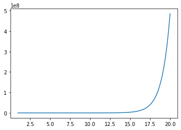

```python
# data
import numpy as np
X = np.linspace(1,20,100)
Y = np.exp(X)

# line plot
plt.plot(X,Y)

# display the plot
plt.show()
```

From the plot, it can be observed that as 'X' is increasing there is an exponential increase in Y.

**The above plot can be represented not only by a solid line, but also a dotted line with varied thickness. The points can be marked explicitly using any symbol.**

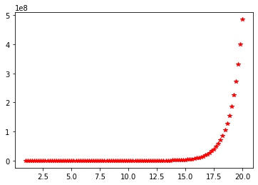

```python
# data
X = np.linspace(1,20,100)
Y = np.exp(X)

# line plot
# the argument 'r*' plots each point as a red '*'
plt.plot(X,Y, 'r*')

# display the plot
plt.show()
```

We can change the colors or shapes of the data points.

There can be multiple line plots in one plot. Let's plot three plots together in a single graph. Also, add a plot title.

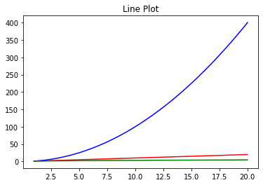

```python
# data
X = np.linspace(1,20,100)
Y1 = X
Y2 = np.square(X)
Y3 = np.sqrt(X)

# line plot
plt.plot(X,Y1,'r', X,Y2,'b', X,Y3,'g')

# add title to the plot
plt.title('Line Plot')

# display the plot
plt.show()
```

### 1.2 Scatter Plot

| **A scatter plot is a set of points plotted on horizontal and vertical axes. The scatter plot can be used to study the correlation between the two variables. One can also detect the extreme data point… |
| --- |

```python
# check the head() of the tips dataset
tips_data.head()
```

|  | total_bill | tip | sex | smoker | day | time | size |
| --- | --- | --- | --- | --- | --- | --- | --- |
| 0 | 16.99 | 1.01 | Female | No | Sun | Dinner | 2 |
| 1 | 10.34 | 1.66 | Male | No | Sun | Dinner | 3 |
| 2 | 21.01 | 3.50 | Male | No | Sun | Dinner | 3 |
| 3 | 23.68 | 3.31 | Male | No | Sun | Dinner | 2 |
| 4 | 24.59 | 3.61 | Female | No | Sun | Dinner | 4 |

Plot the scatter plot for the variables 'total_bill' and 'tip'

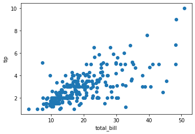

```python
# data
X = tips_data['total_bill']
Y = tips_data['tip']

# plot the scatter plot
plt.scatter(X,Y)

# add the axes labels to the plot
plt.xlabel('total_bill')
plt.ylabel('tip')

# display the plot
plt.show()
```

We can add different colors, opacity, and shape of data points. Let's add these customizations in the above plot.

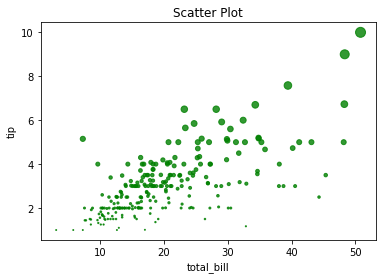

```python
# plot the scatter plot for the variables 'total_bill' and 'tip'

X = tips_data['total_bill']
Y = tips_data['tip']

# plot the scatter plot
# s is for shape, c is for colour, alpha is for opacity (0 < alpha < 1)
plt.scatter(X, Y, s = np.array(Y)**2, c= 'green', alpha= 0.8)

# add title
plt.title('Scatter Plot')

# add the axes labels to the plot
plt.xlabel('total_bill')
plt.ylabel('tip')

# display the plot
plt.show()
```

The bubbles with greater radius display that the tip amount is more as compared to the bubbles with less radius.

### 1.3 Bar Plot

A bar plot is used to display categorical data with bars with lengths proportional to the values that they represent. The comparison between different categories of a categorical variable can be done by studying a bar plot.  
In the vertical bar plot, the X-axis displays the categorical variable and Y-axis contains the values corresponding to different categories.

```python
# check the head() of the tips dataset
tips_data.head()
```

|  | total_bill | tip | sex | smoker | day | time | size |
| --- | --- | --- | --- | --- | --- | --- | --- |
| 0 | 16.99 | 1.01 | Female | No | Sun | Dinner | 2 |
| 1 | 10.34 | 1.66 | Male | No | Sun | Dinner | 3 |
| 2 | 21.01 | 3.50 | Male | No | Sun | Dinner | 3 |
| 3 | 23.68 | 3.31 | Male | No | Sun | Dinner | 2 |
| 4 | 24.59 | 3.61 | Female | No | Sun | Dinner | 4 |

```python
# the variable 'smoker' is categorical
# check categories in the variable
set(tips_data['smoker'])
```

```
{'No', 'Yes'}
```

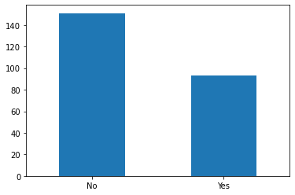

```python
# bar plot to get the count of smokers and non-smokers in the data

# kind='bar' plots a bar plot
# 'rot = 0' returns the categoric labels horizontally
tips_data.smoker.value_counts().plot(kind='bar', rot = 0)

# display the plot
plt.show()
```

Let's add the count of smokers and non-smokers, axes labels and title to the above plot

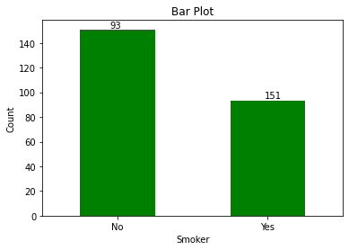

```python
# bar plot to get the count of smokers and non-smokers in the data

# kind='bar' plots a bar plot
# 'rot = 0' returns the categoric labels horizontally
# 'color' can be used to add a specific colour
tips_data.smoker.value_counts().plot(kind='bar', rot = 0, color = 'green')

# plt.text() adds the text to the plot
# x and y are positions on the axes
# s is the text to be added
plt.text(x = -0.05, y = tips_data.smoker.value_counts()[0]+1, s = tips_data.smoker.value_counts()[1])
plt.text(x = 0.98, y = tips_data.smoker.value_counts()[1]+2, s = tips_data.smoker.value_counts()[0])

# add title and axes labels
plt.title('Bar Plot')
plt.xlabel('Smoker')
plt.ylabel('Count')

# display the plot
plt.show()
```

From the bar plot, it can be interpreted that the proportion of non-smokers is more in the data

### 1.4 Pie Plot

| **Pie plot is a graphical representation of univariate data. It is a circular graph divided into slices displaying the numerical proportion. For the categorical variable, each slice of the pie plot co… |
| --- |

```python
# check the head() of the tips dataset
tips_data.head()
```

|  | total_bill | tip | sex | smoker | day | time | size |
| --- | --- | --- | --- | --- | --- | --- | --- |
| 0 | 16.99 | 1.01 | Female | No | Sun | Dinner | 2 |
| 1 | 10.34 | 1.66 | Male | No | Sun | Dinner | 3 |
| 2 | 21.01 | 3.50 | Male | No | Sun | Dinner | 3 |
| 3 | 23.68 | 3.31 | Male | No | Sun | Dinner | 2 |
| 4 | 24.59 | 3.61 | Female | No | Sun | Dinner | 4 |

```python
# categories in the 'day' variable
tips_data.day.value_counts()
```

```
Sat     87
Sun     76
Thur    62
Fri     19
Name: day, dtype: int64
```

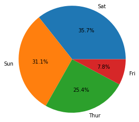

```python
# plot the occurrence of different days in the dataset

# 'autopct' displays the percentage upto 1 decimal place
# 'radius' sets the radius of the pie plot
plt.pie(tips_data.day.value_counts(), autopct = '%.1f%%', radius = 1.2, labels = ['Sat', 'Sun','Thur','Fri'])

# display the plot
plt.show()
```

From the above pie plot, it can be seen that the data has a high proportion for Saturday followed by Sunday.

**Exploded pie plot** is a plot in which one or more sectors are separated from the disc

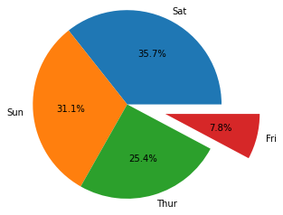

```python
# plot the occurrence of different days in the dataset

# exploded pie plot
plt.pie(tips_data.day.value_counts(), autopct = '%.1f%%', radius = 1.2, labels = ['Sat', 'Sun','Thur','Fri'],
        explode = [0,0,0,0.5])

# display the plot
plt.show()
```

**Donut pie plot** is a type of pie plot in which there is a hollow center representing a doughnut.

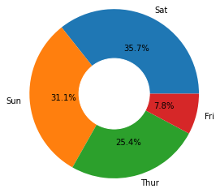

```python
# plot the occurrence of different days in the dataset

# pie plot
plt.pie(tips_data.day.value_counts(), autopct = '%.1f%%', radius = 1.2, labels = ['Sat', 'Sun','Thur','Fri'])

# add a circle at the center
circle =  plt.Circle( (0,0), 0.5, color='white')
plot = plt.gcf()
plot.gca().add_artist(circle)

# display the plot
plt.show()
```

### 1.5 Histogram

| **A histogram is used to display the distribution and spread of the continuous variable. One axis represents the range of variable and the other axis shows the frequency of the data points. In a histo… |
| --- |

```python
# check the head() of the tips dataset
tips_data.head()
```

|  | total_bill | tip | sex | smoker | day | time | size |
| --- | --- | --- | --- | --- | --- | --- | --- |
| 0 | 16.99 | 1.01 | Female | No | Sun | Dinner | 2 |
| 1 | 10.34 | 1.66 | Male | No | Sun | Dinner | 3 |
| 2 | 21.01 | 3.50 | Male | No | Sun | Dinner | 3 |
| 3 | 23.68 | 3.31 | Male | No | Sun | Dinner | 2 |
| 4 | 24.59 | 3.61 | Female | No | Sun | Dinner | 4 |

In tips dataset, 'tip' is the continuous variable. Let's plot the histogram to understand the distribution of the variable.

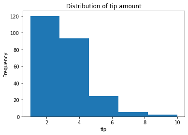

```python
# plot the histogram
# specify the number of bins, using 'bins' parameter
plt.hist(tips_data['tip'], bins= 5)

# add the graph title and axes labels
plt.title('Distribution of tip amount')
plt.xlabel('tip')
plt.ylabel('Frequency')

# display the plot
plt.show()
```

From the above plot, we can see that the tip amount is positively skewed.

### 1.6 Box Plot

**Boxplot is a way to visualize the five-number summary of the variable. The five-number summary includes the numerical quantities like minimum, first quartile (Q1), median (Q2), third quartile (Q3), and maximum. Boxplot gives information about the outliers in the data. Detecting and removing outliers is one of the most important steps in exploratory data analysis. Boxplots also tells about the distribution of the data.**

```python
# check the head() of the tips dataset
tips_data.head()
```

|  | total_bill | tip | sex | smoker | day | time | size |
| --- | --- | --- | --- | --- | --- | --- | --- |
| 0 | 16.99 | 1.01 | Female | No | Sun | Dinner | 2 |
| 1 | 10.34 | 1.66 | Male | No | Sun | Dinner | 3 |
| 2 | 21.01 | 3.50 | Male | No | Sun | Dinner | 3 |
| 3 | 23.68 | 3.31 | Male | No | Sun | Dinner | 2 |
| 4 | 24.59 | 3.61 | Female | No | Sun | Dinner | 4 |

Plot the boxplot of 'total_bill' to check the distribution and presence of outliers in the variable.

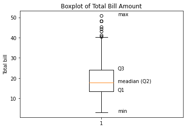

```python
# plot a distribution of total bill
plt.boxplot(tips_data['total_bill'])

# add labels for five number summary
plt.text(x = 1.1, y = tips_data['total_bill'].min(), s ='min')
plt.text(x = 1.1, y = tips_data.total_bill.quantile(0.25), s ='Q1')
plt.text(x = 1.1, y = tips_data['total_bill'].median(), s ='meadian (Q2)')
plt.text(x = 1.1, y = tips_data.total_bill.quantile(0.75), s ='Q3')
plt.text(x = 1.1, y = tips_data['total_bill'].max(), s ='max')


# add the graph title and axes labels
plt.title('Boxplot of Total Bill Amount')
plt.ylabel('Total bill')

# display the plot
plt.show()
```

The above boxplot clearly shows the presence of outliers above the horizontal line. We can add an arrow to showcase the outliers. Also, the median (Q2) is represented by the orange line, which is near to Q1 rather than Q3. This shows that the total bill is positively skewed.

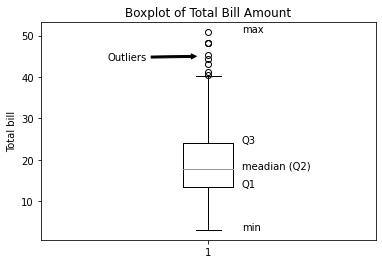

```python
# plot a distribution of total bill
plt.boxplot(tips_data['total_bill'])

# add labels for five number summary
plt.text(x = 1.1, y = tips_data['total_bill'].min(), s ='min')
plt.text(x = 1.1, y = tips_data.total_bill.quantile(0.25), s ='Q1')
plt.text(x = 1.1, y = tips_data['total_bill'].median(), s ='meadian (Q2)')
plt.text(x = 1.1, y = tips_data.total_bill.quantile(0.75), s ='Q3')
plt.text(x = 1.1, y = tips_data['total_bill'].max(), s ='max')

# add an arrow (annonate) to show the outliers
plt.annotate('Outliers', xy = (0.97,45),xytext=(0.7, 44), arrowprops = dict(facecolor='black', arrowstyle = 'simple'))

# add the graph title and axes labels
plt.title('Boxplot of Total Bill Amount')
plt.ylabel('Total bill')

# display the plot
plt.show()
```

## 2. Plots using Seaborn

Seaborn is a Python visualization library based on matplotlib. The library provides a high-level interface for plotting statistical graphics. As the library uses matplotlib in the backend, we can use the functions in matplotlib along with functions in seaborn.  
Various functions in the seaborn library allow us to plot complex and advance statistical plots like linear/higher-order regression, univariate/multivariate distribution, violin, swarm, strip plots, correlations and so on.

**How to install Seaborn?**

1. You can use-  
   `!pip install seaborn`

### 2.1 Strip Plot

| **The strip plot resembles a scatterplot when one variable is categorical. This plot can help study the underlying distribution.** |
| --- |

```python
# check the head() of the tips dataset
tips_data.head()
```

|  | total_bill | tip | sex | smoker | day | time | size |
| --- | --- | --- | --- | --- | --- | --- | --- |
| 0 | 16.99 | 1.01 | Female | No | Sun | Dinner | 2 |
| 1 | 10.34 | 1.66 | Male | No | Sun | Dinner | 3 |
| 2 | 21.01 | 3.50 | Male | No | Sun | Dinner | 3 |
| 3 | 23.68 | 3.31 | Male | No | Sun | Dinner | 2 |
| 4 | 24.59 | 3.61 | Female | No | Sun | Dinner | 4 |

Plot a strip plot to check the relationship between the variables 'tip' and 'time'

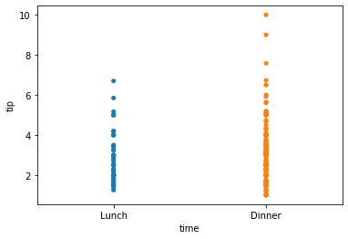

```python
# strip plot
sns.stripplot(y = 'tip', x = 'time', data = tips_data, jitter=False)

# display the plot
plt.show()
```

It can be seen that the tip amount is more at dinner time than at lunchtime. But the above plot is unable to display the spread of the data. We can plot the points with spread using the jitter = True parameter in the stripplot function which is also the default value of jitter.

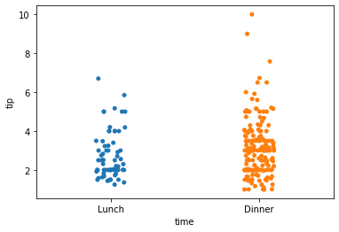

```python
# strip plot with jitter to spread the points
sns.stripplot(y = 'tip', x = 'time', data = tips_data, jitter = True)

# display the plot
plt.show()
```

The plot shows that for most of the observations the tip amount is in the range 1 to 3 irrespective of the time.

### 2.2 Swarm Plot

| **The swarm plot is similar to the strip plot but it avoids the overlapping of the points. This can give a better representation of the distribution of the data.** |
| --- |

```python
# check the head() of the tips dataset
tips_data.head()
```

|  | total_bill | tip | sex | smoker | day | time | size |
| --- | --- | --- | --- | --- | --- | --- | --- |
| 0 | 16.99 | 1.01 | Female | No | Sun | Dinner | 2 |
| 1 | 10.34 | 1.66 | Male | No | Sun | Dinner | 3 |
| 2 | 21.01 | 3.50 | Male | No | Sun | Dinner | 3 |
| 3 | 23.68 | 3.31 | Male | No | Sun | Dinner | 2 |
| 4 | 24.59 | 3.61 | Female | No | Sun | Dinner | 4 |

Plot the swarm plot for the variables 'tip' and 'time'.

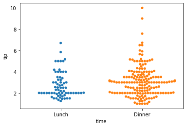

```python
# swarm plot
sns.swarmplot(y = 'tip', x = 'time', data = tips_data)

# display the plot
plt.show()
```

The above plot gives a good representation of the tip amount for the time. It can be seen that the tip amount is 2 for most of the observations. We can see that the swarm plot gives a better understanding of the variables than the strip plot.

We can add another categorical variable in the above plot by using a parameter 'hue'.

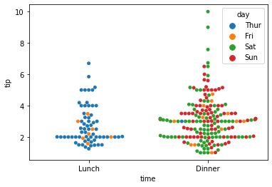

```python
# swarm plot with one more categorical variable 'day'
sns.swarmplot(y = 'tip', x = 'time', data = tips_data, hue = 'day')

# display the plot
plt.show()
```

The plot shows that the tip was collected at lunchtime only on Thursday and Friday. The amount of tips collected at dinner time on Saturday is the highest.

### 2.3 Violin Plot

| **The violin plot is similar to a box plot that features a kernel density estimation of the underlying distribution. The plot shows the distribution of numerical variables across categories of one (or… |
| --- |

```python
# check the head() of the tips dataset
tips_data.head()
```

|  | total_bill | tip | sex | smoker | day | time | size |
| --- | --- | --- | --- | --- | --- | --- | --- |
| 0 | 16.99 | 1.01 | Female | No | Sun | Dinner | 2 |
| 1 | 10.34 | 1.66 | Male | No | Sun | Dinner | 3 |
| 2 | 21.01 | 3.50 | Male | No | Sun | Dinner | 3 |
| 3 | 23.68 | 3.31 | Male | No | Sun | Dinner | 2 |
| 4 | 24.59 | 3.61 | Female | No | Sun | Dinner | 4 |

Let's draw a violin plot for the numerical variable 'total_bill' and a categorical variable 'day'.

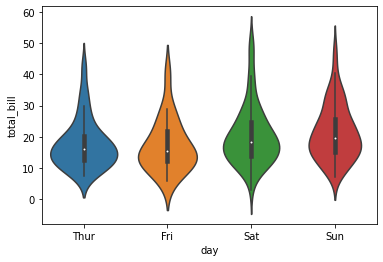

```python
# violin plot
sns.violinplot(y = 'total_bill', x = 'day', data = tips_data)

# display the plot
plt.show()
```

The above violin plot shows that the total bill distribution is nearly the same for different days. We can add another categorical variable 'sex' to the above plot to get an insight into the bill amount distribution based on days as well as gender.

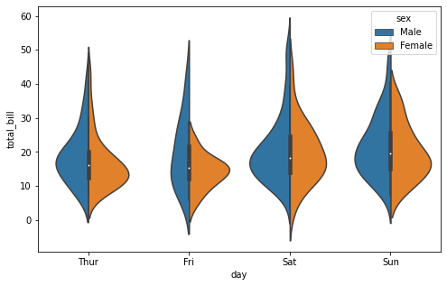

```python
# set the figure size
plt.figure(figsize = (8,5))

# violin plot with addition of the variable 'sex'
# 'split = True' draws half plot for each of the category of 'sex'
sns.violinplot(y = 'total_bill', x = 'day', data = tips_data, hue = 'sex', split = True)

# display the plot
plt.show()
```

There is no significant difference in the distribution of bill amount and sex.

### 2.4 Pair Plot

| **The pair plot gives a pairwise distribution of variables in the dataset. pairplot() function creates a matrix such that each grid shows the relationship between a pair of variables. On the diagonal … |
| --- |

```python
# check the head() of the tips dataset
tips_data.head()
```

|  | total_bill | tip | sex | smoker | day | time | size |
| --- | --- | --- | --- | --- | --- | --- | --- |
| 0 | 16.99 | 1.01 | Female | No | Sun | Dinner | 2 |
| 1 | 10.34 | 1.66 | Male | No | Sun | Dinner | 3 |
| 2 | 21.01 | 3.50 | Male | No | Sun | Dinner | 3 |
| 3 | 23.68 | 3.31 | Male | No | Sun | Dinner | 2 |
| 4 | 24.59 | 3.61 | Female | No | Sun | Dinner | 4 |

Plot a pair plot for the tips dataset

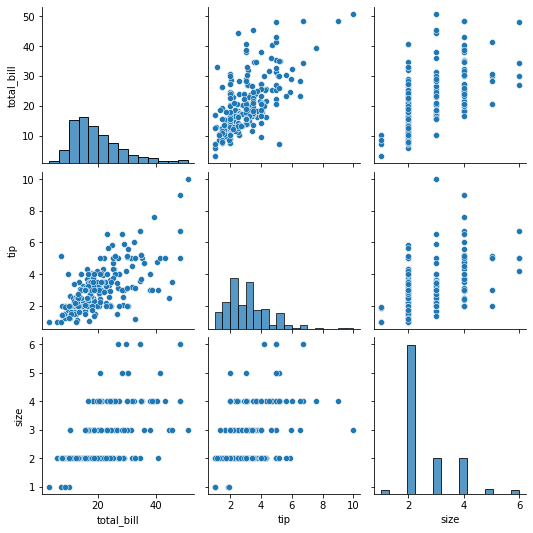

```python
# set the figure size
plt.figure(figsize = (8,8))

# plot a pair plot
sns.pairplot(tips_data)

# display the plot
plt.show()
```

The above plot shows the relationship between all the numerical variables. 'total_bill' and 'tip' has a positive linear relationship with each other. Also, 'total_bill' and 'tip' are positively skewed. 'size' has a significant impact on the 'total_bill', as the minimum bill amount is increasing with an increasing number of customers (size).

### 2.5 Distribution Plot

| **A seaborn provides a displot() function which is used to visualize a distribution of the univariate variable. This function uses matplotlib to plot a histogram and fit a kernel density estimate (KDE… |
| --- |

```python
# check the head() of the tips dataset
tips_data.head()
```

|  | total_bill | tip | sex | smoker | day | time | size |
| --- | --- | --- | --- | --- | --- | --- | --- |
| 0 | 16.99 | 1.01 | Female | No | Sun | Dinner | 2 |
| 1 | 10.34 | 1.66 | Male | No | Sun | Dinner | 3 |
| 2 | 21.01 | 3.50 | Male | No | Sun | Dinner | 3 |
| 3 | 23.68 | 3.31 | Male | No | Sun | Dinner | 2 |
| 4 | 24.59 | 3.61 | Female | No | Sun | Dinner | 4 |

Lets plot a distribution plot of 'total_bill'

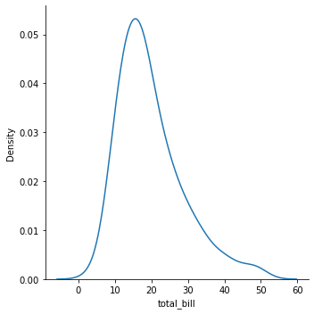

```python
# plot a distribution plot
sns.displot(tips_data['total_bill'], kind='kde')

# display the plot
plt.show()
```

We can interpret from the above plot that the total bill amount is between the range 10 to 20 for a large number of observations. The distribution plot can be used to visualize the total bill for different times of the day. We can use the hue parameter to visualize the total bill with respect to time.

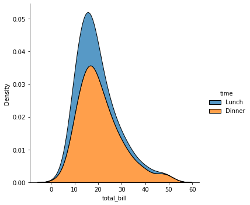

```python
sns.displot(data=tips_data, x='total_bill', hue='time', kind='kde', multiple= 'stack')
```

It can be seen that the distribution plot for lunch is more right-skewed than a plot for dinner. This implies that the customers are spending more on dinner rather than lunch.

```python
# # iterate the distplot() function over the time

# # list of time
# time = ['Lunch', 'Dinner']

# # iterate through time
# for i in time:
#     subset = tips_data[tips_data['time'] == i]

# # Draw the density plot`
# # 'hist = False' will not plot a histogram
# # 'kde = True' plots density curve
#     sns.distplot(subset['total_bill'], hist = False, kde = True,
#                  kde_kws = {'shade':True},
#                  label = i)
```

### 2.6 Count Plot

| **Count plot shows the count of observations in each category of a categorical variable. We can add another variable using a parameter 'hue'.** |
| --- |

```python
# check the head() of the tips dataset
tips_data.head()
```

|  | total_bill | tip | sex | smoker | day | time | size |
| --- | --- | --- | --- | --- | --- | --- | --- |
| 0 | 16.99 | 1.01 | Female | No | Sun | Dinner | 2 |
| 1 | 10.34 | 1.66 | Male | No | Sun | Dinner | 3 |
| 2 | 21.01 | 3.50 | Male | No | Sun | Dinner | 3 |
| 3 | 23.68 | 3.31 | Male | No | Sun | Dinner | 2 |
| 4 | 24.59 | 3.61 | Female | No | Sun | Dinner | 4 |

Let us plot the count of observations for each day based on time

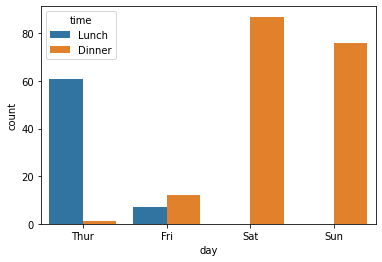

```python
# count of observations for each day based on time
# set 'time' as hue parameter
sns.countplot(data = tips_data, x = 'day', hue = 'time')

# display the plot
plt.show()
```

All the observations recorded on Saturday and Sunday are for dinner. Observations for lunch on Thursday is highest among lunchtime.

### 2.7 Heatmap

Heatmap is a two-dimensional graphical representation of data where the individual values that are contained in a matrix are represented as colors. Each square in the heatmap shows the correlation between variables on each axis.  
Correlation is a statistic that measures the degree to which two variables move with each other.

```python
# check the head() of the tips dataset
tips_data.head()
```

|  | total_bill | tip | sex | smoker | day | time | size |
| --- | --- | --- | --- | --- | --- | --- | --- |
| 0 | 16.99 | 1.01 | Female | No | Sun | Dinner | 2 |
| 1 | 10.34 | 1.66 | Male | No | Sun | Dinner | 3 |
| 2 | 21.01 | 3.50 | Male | No | Sun | Dinner | 3 |
| 3 | 23.68 | 3.31 | Male | No | Sun | Dinner | 2 |
| 4 | 24.59 | 3.61 | Female | No | Sun | Dinner | 4 |

Compute correlation between the variables using .corr() function. Plot a heatmap of the correlation matrix.

```python
# compute correlation
corr_matrix = tips_data.corr()

corr_matrix
```

|  | total_bill | tip | size |
| --- | --- | --- | --- |
| total_bill | 1.000000 | 0.675734 | 0.598315 |
| tip | 0.675734 | 1.000000 | 0.489299 |
| size | 0.598315 | 0.489299 | 1.000000 |

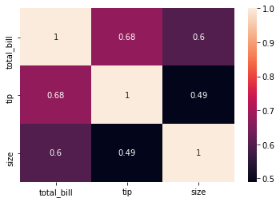

```python
# plot heatmap
# 'annot=True' returns the correlation values
sns.heatmap(corr_matrix, annot = True)

# display the plot
plt.show()
```

The above plot shows that there is a moderate correlation between 'total_bill' and 'tip' (0.68). The diagonal values are '1' as it is the correlation of the variable with itself.